# Basu_Jarva

Davi Simon

2/26/2019

# Replication of Jarva and Lof (2018)

https://poseidon01.ssrn.com/delivery.php?ID=907117081025014127096021000069120072026032046009065078108123…&EXT=pdf

# Identifying accounting conservatismin the presence of skewness

The authors simulate a set of income and retuns from companies, in order to show that when returns are right skewed, the assimetric timeliness coefficient ofthe Basu (1997) model will capture conservatism even when it is not explicitly modeled.

## Simulating Variables

We start by definid the parameter of the simulation Mean

```r
muR <- 0
muI <- 0
```

variance

```r
sigmaR <- 1
sigmaI <- 1
```

Correlations

```r
X1 <- 0.6
```

Number of reps

```r
n = 10000
```

# Simulation of variables

```r
set.seed(1)
dat <- mvrnorm(n, mu = c(muR, muI),
               Sigma = matrix(c(sigmaR, X1,
                                X1    , sigmaI),
                              ncol = 2, byrow = TRUE),
               empirical = TRUE)
```

I used empirical = TRUE to specify empirical not population parameters for μ and Σ. This results in the covariance matrix of dat having exactly the values we specified.

Checking the generated data, we have:

```r
cov(dat)
```

```
##      [,1] [,2]
## [1,]  1.0  0.6
## [2,]  0.6  1.0
```

```r
colMeans(dat)
```

```
## [1] 2.710167e-17 1.676940e-17
```

Running a first model on the generated data, we have the following results:

```r
dat <- as.data.frame(dat)
colnames(dat) = c("Returns", "Income")
dat %<>% mutate(D = ifelse(Returns < 0, 1, 0 ))
model <- lm(Income ~ Returns + D + Returns * D, data=dat)
summary(model)
```

```
##
## Call:
## lm(formula = Income ~ Returns + D + Returns * D, data = dat)
##
## Residuals:
##     Min      1Q  Median      3Q     Max
## -3.5199 -0.5376 -0.0018  0.5305  3.1519
##
## Coefficients:
##               Estimate Std. Error t value Pr(>|t|)
## (Intercept)  1.420e-03  1.925e-02   0.074    0.941
## Returns      5.989e-01  1.917e-02  31.240   <2e-16 ***
## D           -2.853e-03  2.679e-02  -0.106    0.915
## Returns:D   -5.217e-05  2.679e-02  -0.002    0.998
## ---
## Signif. codes:  0 '***' 0.001 '**' 0.01 '*' 0.05 '.' 0.1 ' ' 1
##
## Residual standard error: 0.8001 on 9996 degrees of freedom
## Multiple R-squared:   0.36,  Adjusted R-squared:  0.3598
## F-statistic:  1874 on 3 and 9996 DF,  p-value: < 2.2e-16
```

## Transformation 1 Skewed Returns

Based on the description provided by the authors in footnote 9, we obtained the place of cdf of each variable, based on the cdf of the standard normal distribution throzgh object S_R, and then based on the skewed standard normal cdf, generated returns the position of the quantiles from the previous step.

```r
#from standard normal
S_R <- pnorm(dat$Returns,0,1)
#now on the skewed normal distribution
Skewed_Returns <- qsn(S_R, xi=0, omega=1, alpha=10, tau=0)
```

Creating a new data frame to store generated variables, we plot the comparable Returns and Skewed returns

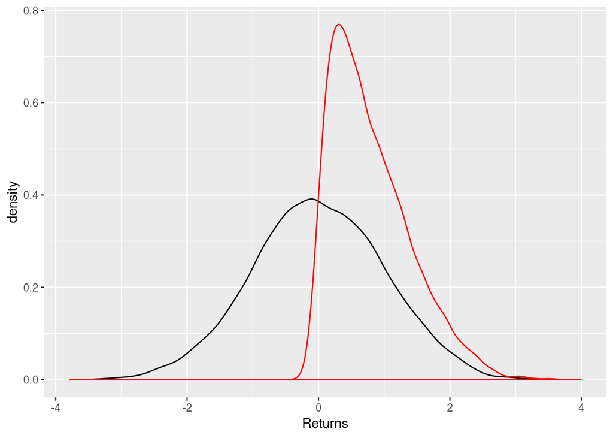

```r
mod_dat <- as.data.frame(cbind(dat$Income,dat$Returns,Skewed_Returns))
colnames(mod_dat) <- c("Income","Returns","Skewed_Returns")
ggplot(mod_dat) + geom_density(aes(x=Returns)) + geom_density(aes(x=Skewed_Returns), color="red")
```

Following, we model the variable D, which is set to 0 when returns are positive, and 1 when returns are negative, following Basu (1997).

```r
mod_dat %<>% mutate(D = ifelse(Returns < 0, 1, 0 ))
mod_dat %<>% mutate(D_Skewed = ifelse(Skewed_Returns < 0, 1, 0 ))
```

## Transformation 2 Skewed Income

Next, we estimate skewed Income and plot it against te original income

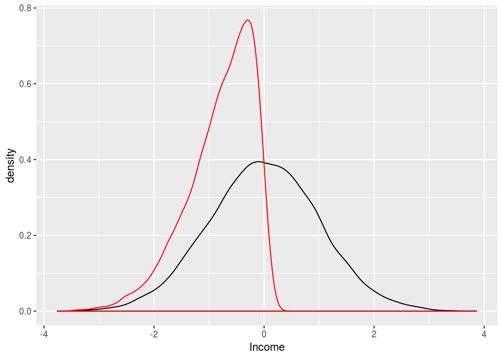

```r
S_I <- pnorm(dat$Income,0,1)
Skewed_Income <- qsn(S_I, xi=0, omega=1, alpha=-10, tau=0)
mod_dat <- cbind(mod_dat,Skewed_Income)
ggplot(mod_dat) + geom_density(aes(x=Income)) + geom_density(aes(x=Skewed_Income), color="red")
```

## Models

At last, we estimate the models:

```r
model <- lm(Income ~ Returns + D + Returns * D, data=mod_dat)
model_skewed_R <- lm(Income ~ Skewed_Returns + D_Skewed + Skewed_Returns * D_Skewed, data=mod_dat)
model_skewed_I <- lm(Skewed_Income ~ Returns + D + Returns * D, data=mod_dat)
model_skewed_I_R <- lm(Skewed_Income ~ Skewed_Returns + D_Skewed + Skewed_Returns * D_Skewed, data=mod_dat)
```

Summary of results

```r
stargazer(model,model_skewed_R,model_skewed_I,model_skewed_I_R, type="html",
          dep.var.labels=c("Income"))
```

|  | *Dependent variable:* |  |  |  |
| --- | --- | --- | --- | --- |
|  | Income |  | Skewed_Income |  |
|  | (1) | (2) | (3) | (4) |
| Returns | 0.599*** |  | 0.265*** |  |
|  | (0.019) |  | (0.012) |  |
| D | -0.003 |  | -0.003 |  |
|  | (0.027) |  | (0.016) |  |
| Returns:D | -0.0001 |  | 0.178*** |  |
|  | (0.027) |  | (0.016) |  |
| Skewed_Returns |  | 0.908*** |  | 0.500*** |
|  |  | (0.014) |  | (0.009) |
| D_Skewed |  | -0.428*** |  | -0.382*** |
|  |  | (0.073) |  | (0.045) |
| Skewed_Returns:D_Skewed |  | 3.443*** |  | 3.164*** |
|  |  | (0.912) |  | (0.566) |
| Constant | 0.001 | -0.700*** | -0.721*** | -1.172*** |
|  | (0.019) | (0.014) | (0.012) | (0.009) |
| Observations | 10,000 | 10,000 | 10,000 | 10,000 |
| R<sup>2</sup> | 0.360 | 0.350 | 0.349 | 0.324 |
| Adjusted R<sup>2</sup> | 0.360 | 0.350 | 0.349 | 0.323 |
| Residual Std. Error (df = 9996) | 0.800 | 0.806 | 0.491 | 0.500 |
| F Statistic (df = 3; 9996) | 1,874.256*** | 1,794.417*** | 1,789.054*** | 1,594.104*** |
| *Note:* | p<0.1; p<0.05; p<0.01 |  |  |  |

Correlation Structure of the original and modified variables

```r
stargazer(cor(mod_dat),type="html")
```

|  | Income | Returns | Skewed_Returns | D | D_Skewed | Skewed_Income |
| --- | --- | --- | --- | --- | --- | --- |
| Income | 1 | 0.600 | 0.581 | -0.482 | -0.256 | 0.968 |
| Returns | 0.600 | 1 | 0.969 | -0.802 | -0.411 | 0.585 |
| Skewed_Returns | 0.581 | 0.969 | 1 | -0.793 | -0.259 | 0.543 |
| D | -0.482 | -0.802 | -0.793 | 1 | 0.182 | -0.468 |
| D_Skewed | -0.256 | -0.411 | -0.259 | 0.182 | 1 | -0.297 |
| Skewed_Income | 0.968 | 0.585 | 0.543 | -0.468 | -0.297 | 1 |

# are these results sensible to the level of alpha?

```r
data_frame_sims <- data.frame()
sequence <- seq(from = 0, to = 10, by = 0.5)
for (i in seq_along(sequence))
{
  S_R <- pnorm(dat$Returns,0,1)
  Skewed_Returns <- qsn(S_R, xi=0, omega=1, alpha=sequence[i], tau=0)
  # dataframe of Data
  mod_dat <- as.data.frame(cbind(dat$Income,dat$Returns,Skewed_Returns))
  colnames(mod_dat) <- c("Income","Returns","Skewed_Returns")
  mod_dat %<>% mutate(D_Skewed = ifelse(Skewed_Returns < 0, 1, 0 ))
  model_skewed_R_i <- lm(Income ~ Skewed_Returns + D_Skewed + Skewed_Returns * D_Skewed, data=mod_dat)
  data_frame_sims[i,1] <- sequence[i]
  data_frame_sims[i,2] <- coefficients(summary(model_skewed_R_i))[4,1]
  data_frame_sims[i,3] <- coefficients(summary(model_skewed_R_i))[4,4]
  }
colnames(data_frame_sims) <- c("Alpha","Coefficient D x Skewed_Returns","p-value")
```

Examining the results:

```r
kable(data_frame_sims) %>%
  kable_styling() %>%
  scroll_box(width = "100%", height = "200px")
```

| Alpha | Coefficient D x Skewed_Returns | p-value |
| --- | --- | --- |
| 0.0 | -0.0000522 | 0.9984461 |
| 0.5 | 0.0207473 | 0.5062565 |
| 1.0 | 0.1327112 | 0.0027991 |
| 1.5 | 0.2418644 | 0.0001755 |
| 2.0 | 0.5013061 | 0.0000000 |
| 2.5 | 0.7425756 | 0.0000000 |
| 3.0 | 0.9138869 | 0.0000000 |
| 3.5 | 1.0905728 | 0.0000000 |
| 4.0 | 1.2156226 | 0.0000002 |
| 4.5 | 1.3546760 | 0.0000009 |
| 5.0 | 1.4770228 | 0.0000045 |
| 5.5 | 1.7426872 | 0.0000023 |
| 6.0 | 1.6758842 | 0.0000590 |
| 6.5 | 1.7999065 | 0.0001373 |
| 7.0 | 2.3365351 | 0.0000100 |
| 7.5 | 2.8132252 | 0.0000016 |
| 8.0 | 2.9344850 | 0.0000045 |
| 8.5 | 3.1671578 | 0.0000063 |
| 9.0 | 3.0644518 | 0.0000600 |
| 9.5 | 3.4801938 | 0.0000300 |
| 10.0 | 3.4429368 | 0.0001610 |

Following, Jarva and Lof simulate Ball, Kothari and Nikolaev (2013), with added skewness.

…